# NFL GM Evaluation: Predicting Playoff Outcomes from Cap Allocation

> **Persona:** The Owner — an NFL team owner evaluating whether to retain or replace their current GM based on cap behaviors and roster construction patterns, not wins and losses alone.

**Research Question Driving the Model:**  
Can we predict whether a team makes the playoffs based solely on how their GM allocated the salary cap that season?

**Analytical Technique:** Binary Classification using a Decision Tree  
**Target Variable:** `made_playoffs` (True / False)  
**Features:** Cap allocation metrics derived from `team_seasons_enriched`

## Setup

```python
# data tools
import polars as pl
import pandas as pd
import polars.selectors as cs
import numpy as np
import random

# graphing tools
import altair as alt
import matplotlib.pyplot as plt

# sklearn config
from sklearn import set_config

# modeling
from sklearn.model_selection import train_test_split
from sklearn import tree

# inspection and evaluation
from sklearn.metrics import ConfusionMatrixDisplay, classification_report

# colab secrets
from google.colab import userdata

# github access
import subprocess
import os
```

```python
alt.data_transformers.disable_max_rows()
set_config(transform_output='polars')
random.seed(42)  # For reproducibility.
```

## Loading Data

We load `team_seasons_enriched` directly from our GitHub repository using the `gm-git-token` secret stored in Colab. This table was produced in the wrangling notebook and contains one row per team per season with all cap allocation features and the `made_playoffs` target already derived.

```python
# Retrieve the GitHub token from Colab Secrets
GH_TOKEN = userdata.get('gm-git-token')
REPO     = 'brandonsbombers/nfl-front-office'
BRANCH   = 'main'
```

```python
# Load team_seasons_enriched from the repository
import urllib.request

url = f'https://raw.githubusercontent.com/{REPO}/{BRANCH}/data/team_seasons_enriched.csv'
req = urllib.request.Request(url, headers={'Authorization': f'token {GH_TOKEN}'})

with urllib.request.urlopen(req) as response:
    raw = response.read()

import io
team_seasons_enriched = pl.read_csv(io.BytesIO(raw))

print(f'Shape: {team_seasons_enriched.shape}')
team_seasons_enriched.head()
```

```
Shape: (480, 22)
```

shape: (5, 22)

| season i64 | team str | wins i64 | losses i64 | ties i64 | playoff_result str | gm_name str | gm_stint_id i64 | franchise_id str | start_year i64 | end_year i64 | total_cap_pct f64 | offensive_cap_pct f64 | defensive_cap_pct f64 | fa_cap_pct f64 | rookie_cap_pct f64 | fa_spend_ratio f64 | rookie_contract_pct f64 | made_playoffs bool | wins_per_cap_pct f64 | fa_spend_ratio_right f64 | rookie_contract_pct_right f64 |
| --- | --- | --- | --- | --- | --- | --- | --- | --- | --- | --- | --- | --- | --- | --- | --- | --- | --- | --- | --- | --- | --- |
| 2011 | "ARI" | 8 | 8 | 0 | "MISSED" | "Rod Graves" | 113 | "F_ARI" | 2003 | 2012 | 43.2 | 35.1 | 8.1 | 21.0 | 8.8 | 48.611111 | 20.37037 | false | 0.185185 | 48.611111 | 20.37037 |
| 2012 | "ARI" | 5 | 11 | 0 | "MISSED" | "Rod Graves" | 113 | "F_ARI" | 2003 | 2012 | 34.8 | 11.2 | 23.6 | 5.9 | 5.9 | 16.954023 | 16.954023 | false | 0.143678 | 16.954023 | 16.954023 |
| 2013 | "ARI" | 10 | 6 | 0 | "MISSED" | "Steve Keim" | 114 | "F_ARI" | 2013 | 2023 | 29.7 | 14.9 | 14.8 | 21.9 | 4.5 | 73.737374 | 15.151515 | false | 0.3367 | 73.737374 | 15.151515 |
| 2014 | "ARI" | 11 | 5 | 0 | "WC" | "Steve Keim" | 114 | "F_ARI" | 2013 | 2023 | 51.6 | 27.0 | 23.1 | 35.4 | 5.3 | 68.604651 | 10.271318 | true | 0.213178 | 68.604651 | 10.271318 |
| 2015 | "ARI" | 13 | 3 | 0 | "CON" | "Steve Keim" | 114 | "F_ARI" | 2013 | 2023 | 47.8 | 23.8 | 23.3 | 32.1 | 4.5 | 67.154812 | 9.414226 | true | 0.271967 | 67.154812 | 9.414226 |

## Finding Good Features

Before modeling, we explore whether the cap allocation features contain enough signal to separate playoff teams from non-playoff teams. If the distributions overlap heavily, the model will struggle.

### Feature Distributions by Playoff Status

```python
# Melt cap features into long form for density comparison
features = ['offensive_cap_pct', 'defensive_cap_pct', 'fa_spend_ratio', 'rookie_contract_pct']

df_long = (
    team_seasons_enriched
    .select(features + ['made_playoffs'])
    .drop_nulls()
    .melt(
        id_vars=['made_playoffs'],
        value_vars=features,
        variable_name='feature',
        value_name='value'
    )
    .with_columns(pl.col('made_playoffs').cast(pl.Utf8))
)

alt.Chart(df_long).transform_density(
    density='value',
    bandwidth=1.5,
    groupby=['feature', 'made_playoffs'],
).mark_area(opacity=0.4).encode(
    alt.X('value:Q').title('Cap % Value'),
    alt.Y('density:Q'),
    alt.Color('made_playoffs:N').title('Made Playoffs'),
    alt.Row('feature:N')
).properties(width=400, height=80).resolve_scale(x='independent', y='independent')
```

[interactive chart not shown]

### Feature vs. Target: Scatterplot Matrix

```python
df_plot = (
    team_seasons_enriched
    .select(features + ['made_playoffs'])
    .drop_nulls()
    .with_columns(pl.col('made_playoffs').cast(pl.Utf8))
    .sample(n=min(500, team_seasons_enriched.height), seed=42)
)

alt.Chart(df_plot).mark_point(opacity=0.5).encode(
    alt.X(alt.repeat('column'), type='quantitative'),
    alt.Y(alt.repeat('row'), type='quantitative'),
    color=alt.Color('made_playoffs:N').title('Made Playoffs')
).properties(
    width=150, height=150
).repeat(
    row=features,
    column=features
)
```

[interactive chart not shown]

## Modeling Workflow

We follow the standard sklearn estimator workflow:

1. Prepare features and target
2. Split into training and test sets
3. Initialize the model
4. Train the model
5. Generate predictions
6. Evaluate performance

### Step 1 — Prepare Features and Target

```python
FEATURES = ['offensive_cap_pct', 'defensive_cap_pct', 'fa_spend_ratio', 'rookie_contract_pct']
TARGET   = 'made_playoffs'

modeling_df = (
    team_seasons_enriched
    .select(FEATURES + [TARGET])
    .drop_nulls()
)

X = modeling_df.select(FEATURES)
y = modeling_df.select(TARGET)

print(f'Features (X): {X.shape}')
print(f'Target   (y): {y.shape}')
print(f'\nClass balance:')
print(y.group_by(TARGET).agg(pl.len().alias('count')).sort(TARGET))
```

```
Features (X): (480, 4)
Target   (y): (480, 1)

Class balance:
shape: (2, 2)
┌───────────────┬───────┐
│ made_playoffs ┆ count │
│ ---           ┆ ---   │
│ bool          ┆ u32   │
╞═══════════════╪═══════╡
│ false         ┆ 303   │
│ true          ┆ 177   │
└───────────────┴───────┘
```

### Step 2 — Split into Training and Test Sets

```python
X_train, X_test, y_train, y_test = train_test_split(
    X, y, test_size=0.3, random_state=42
)

print(f'X_train: {X_train.shape}')
print(f'X_test:  {X_test.shape}')
```

```
X_train: (336, 4)
X_test:  (144, 4)
```

### Step 3 — Initialize the Model

```python
model = tree.DecisionTreeClassifier(max_depth=4, random_state=42)
print(model)
```

```
DecisionTreeClassifier(max_depth=4, random_state=42)
```

### Step 4 — Train the Model

```python
model.fit(X_train, y_train)
```

```
DecisionTreeClassifier(max_depth=4, random_state=42)
```

### Step 5 — Generate Predictions

```python
predictions = model.predict(X_test)
predictions[:10]
```

```
array([ True, False,  True, False, False, False, False, False, False,
       False])
```

## Model Evaluation

- **Accuracy score** — overall correctness
- **Classification report** — precision, recall, and F1 by class
- **Confusion matrix** — where the model makes mistakes
- **Decision tree visualization** — which features drive the splits

### Accuracy Score

```python
accuracy = model.score(X_test, y_test)
print(f'Mean Accuracy Score: {accuracy:.4f}')
```

```
Mean Accuracy Score: 0.5417
```

### Classification Report

```python
print(classification_report(
    y_test.to_series().to_list(),
    predictions,
    target_names=['Missed Playoffs', 'Made Playoffs']
))
```

```
                 precision    recall  f1-score   support

Missed Playoffs       0.57      0.82      0.67        82
  Made Playoffs       0.42      0.18      0.25        62

       accuracy                           0.54       144
      macro avg       0.50      0.50      0.46       144
   weighted avg       0.51      0.54      0.49       144
```

### Confusion Matrix

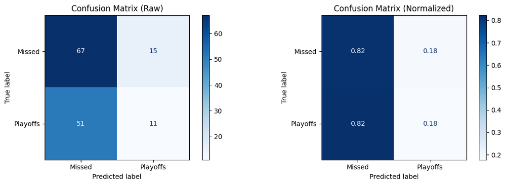

```python
fig, axes = plt.subplots(1, 2, figsize=(12, 4))

for ax, (title, normalize) in zip(axes, [
    ('Confusion Matrix (Raw)', None),
    ('Confusion Matrix (Normalized)', 'true')
]):
    disp = ConfusionMatrixDisplay.from_estimator(
        model, X_test, y_test,
        display_labels=['Missed', 'Playoffs'],
        cmap=plt.cm.Blues,
        normalize=normalize,
        ax=ax
    )
    ax.set_title(title)

plt.tight_layout()
plt.show()
```

### Decision Tree Structure

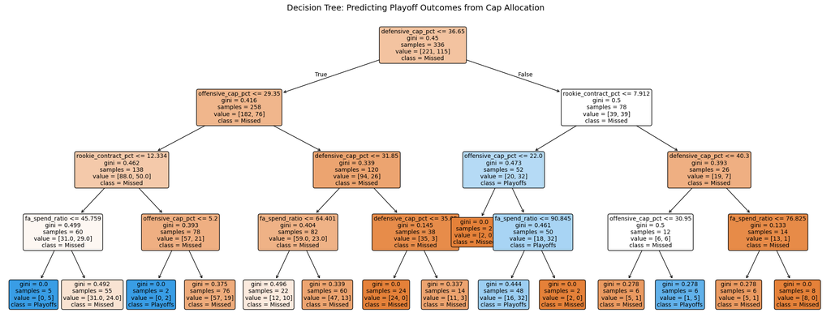

```python
plt.figure(figsize=(20, 8))
tree.plot_tree(
    model,
    feature_names=FEATURES,
    class_names=['Missed', 'Playoffs'],
    filled=True,
    rounded=True,
    fontsize=10
)
plt.title('Decision Tree: Predicting Playoff Outcomes from Cap Allocation', fontsize=14)
plt.tight_layout()
plt.show()
```

### Feature Importance

```python
importance_df = (
    pl.DataFrame({
        'feature':   FEATURES,
        'importance': model.feature_importances_
    })
    .sort('importance', descending=True)
)

alt.Chart(importance_df).mark_bar().encode(
    alt.X('importance:Q').title('Gini Importance'),
    alt.Y('feature:N').sort('-x').title('Cap Feature'),
    alt.Color('importance:Q').scale(scheme='blues').legend(None)
).properties(
    width=400,
    height=150,
    title='Feature Importance: Which Cap Metrics Best Predict Playoff Outcomes?'
)
```

[interactive chart not shown]

## Publishing Results to GitHub

Once the notebook has been run and reviewed, we commit it back to the `nfl-front-office` repository using the `gm-git-token` secret.

```python
import shutil

# Configure git identity
os.system('git config --global user.email "colab@nfl-gm-project.com"')
os.system('git config --global user.name "Brandon Gill"')

# Clone the repository using the token
repo_url = f'https://{GH_TOKEN}@github.com/{REPO}.git'
os.system(f'git clone {repo_url} /content/nfl-front-office')
```

```
0
```

```python
# PUBLISH: Export notebook as HTML to GitHub Pages
import os
import json
from google.colab import userdata, _message

GH_TOKEN = userdata.get('gm-git-token')
REPO     = 'brandonsbombers/nfl-front-office'
BRANCH   = 'main'
REPO_DIR = '/content/nfl-front-office'

# Clone if not already there
if not os.path.exists(REPO_DIR):
    os.system(f'git clone https://{GH_TOKEN}@github.com/{REPO}.git {REPO_DIR}')

os.system(f'git -C {REPO_DIR} config user.email "colab@nfl-gm-project.com"')
os.system(f'git -C {REPO_DIR} config user.name "Brandon Gill"')

# Get the current notebook content
notebook_json = _message.blocking_request('get_ipynb', request='', timeout_sec=60)

# Save notebook to disk temporarily
NB_PATH = '/content/modeling_notebook.ipynb'
with open(NB_PATH, 'w') as f:
    json.dump(notebook_json['ipynb'], f, indent=2)

# Convert to HTML using nbconvert
os.makedirs(f'{REPO_DIR}/docs', exist_ok=True)
os.system(f'jupyter nbconvert --to html {NB_PATH} --output {REPO_DIR}/docs/index.html')

# Commit and push
os.system(f'git -C {REPO_DIR} add docs/')
os.system(f'git -C {REPO_DIR} commit -m "Publish modeling notebook as GitHub Pages"')
os.system(f'git -C {REPO_DIR} push origin {BRANCH}')

print("Done — HTML published to GitHub.")
print(f"Once GitHub Pages is enabled, your site will be at:")
print(f"  https://brandonsbombers.github.io/nfl-front-office")
```

## References

- [Decision trees — scikit-learn](https://scikit-learn.org/stable/modules/tree.html)
- [DecisionTreeClassifier API](https://scikit-learn.org/stable/modules/generated/sklearn.tree.DecisionTreeClassifier.html)
- [Confusion matrix visualization](https://scikit-learn.org/stable/auto_examples/model_selection/plot_confusion_matrix.html)
- [Understanding decision tree structure](https://scikit-learn.org/stable/auto_examples/tree/plot_unveil_tree_structure.html)
- [Cross-validation](https://scikit-learn.org/stable/modules/cross_validation.html)
- [nflreadr documentation](https://nflreadr.nflverse.com/)
- [Google Colab Secrets](https://medium.com/@parthdasawant/how-to-use-secrets-in-google-colab-450c38e3ec75)